# Reproducible Research: Peer Assessment 1

## Loading and preprocessing the data

```r
library(data.table) #install.packages("data.table") if there is no library data.table
library(lattice)
library(ggplot2)
#The reason I use multiple plot library is I am new to R plotting, so for each plot I just googled how to do it(mostly find the answers in http://stackoverflow.com/). Each of the answer uses different plot library.
data=read.csv(unz('activity.zip','activity.csv'))
data <- data.table(data)
summary(data)
```

```
##      steps                date          interval
##  Min.   :  0.00   2012-10-01:  288   Min.   :   0.0
##  1st Qu.:  0.00   2012-10-02:  288   1st Qu.: 588.8
##  Median :  0.00   2012-10-03:  288   Median :1177.5
##  Mean   : 37.38   2012-10-04:  288   Mean   :1177.5
##  3rd Qu.: 12.00   2012-10-05:  288   3rd Qu.:1766.2
##  Max.   :806.00   2012-10-06:  288   Max.   :2355.0
##  NA's   :2304     (Other)   :15840
```

## What is mean total number of steps taken per day?

1. Calculate the total number of steps taken per day

```r
step_sum_by_date <- as.data.frame(data[, j=list(steps = sum(steps, na.rm = TRUE)),by = date])#total number of steps taken per day
head(step_sum_by_date) # the whole data is very long so we just take a look at first 6 entry
```

```
##         date steps
## 1 2012-10-01     0
## 2 2012-10-02   126
## 3 2012-10-03 11352
## 4 2012-10-04 12116
## 5 2012-10-05 13294
## 6 2012-10-06 15420
```

2. Make a histogram of the total number of steps taken each day

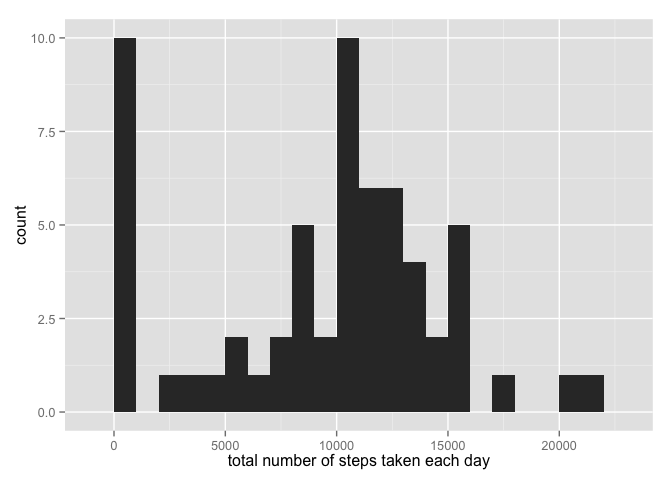

```r
qplot(step_sum_by_date$steps, binwidth = 1000, xlab = "total number of steps taken each day")
```

```r
#there are some days without any step record, here we simplily leave these days here.
```

3. Calculate and report the mean and median of the total number of steps taken per day

```r
mean(step_sum_by_date$steps)#NOTE: days with zero steps are included
```

```
## [1] 9354.23
```

```r
median(step_sum_by_date$steps)
```

```
## [1] 10395
```

## What is the average daily activity pattern?

1. Make a time series plot (i.e. type = “l”) of the 5-minute interval (x-axis) and the average number of steps taken, averaged across all days (y-axis)

```r
step_sum_by_int <- as.data.frame(data[, j=list(steps = mean(steps, na.rm = TRUE)),by = interval])
summary(step_sum_by_int)
```

```
##     interval          steps
##  Min.   :   0.0   Min.   :  0.000
##  1st Qu.: 588.8   1st Qu.:  2.486
##  Median :1177.5   Median : 34.113
##  Mean   :1177.5   Mean   : 37.383
##  3rd Qu.:1766.2   3rd Qu.: 52.835
##  Max.   :2355.0   Max.   :206.170
```

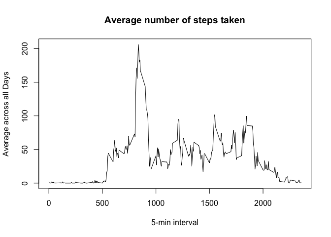

```r
plot(step_sum_by_int$interval, step_sum_by_int$steps, type = "l", xlab = "5-min interval",
    ylab = "Average across all Days", main = "Average number of steps taken")
```

2. Which 5-minute interval, on average across all the days in the dataset, contains the maximum number of steps?

```r
step_sum_by_int[which.max(step_sum_by_int$steps),]
```

```
##     interval    steps
## 104      835 206.1698
```

```r
sum(is.na(data))
```

```
## [1] 2304
```

2. Devise a strategy for filling in all of the missing values in the dataset.
3. Create a new dataset that is equal to the original dataset but with the missing data filled in. we fill the missing val with average of corresponding interval.

```r
new_data <- data
for (i in 1:nrow(data)){
  if (is.na(data$steps[i])){
    interval_val <- data$interval[i]
    steps_val <- step_sum_by_int$steps[which(step_sum_by_int$interval == interval_val)]
    new_data$steps[i] <- steps_val
  }
}
```

4. Make a histogram of the total number of steps taken each day and Calculate and report the mean and median total number of steps taken per day.

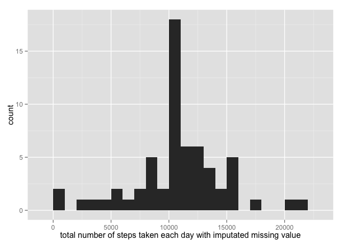

```r
new_step_sum_by_date <- as.data.frame(new_data[, j=list(steps = sum(steps, na.rm = TRUE)),by = date])#total number of steps taken per day
qplot(new_step_sum_by_date$steps, binwidth = 1000, xlab = "total number of steps taken each day with imputated missing value")
```

```r
mean(new_step_sum_by_date$steps)#NOTE: now there are no zero records
```

```
## [1] 10766.19
```

```r
median(new_step_sum_by_date$steps)
```

```
## [1] 10766.19
```

## Are there differences in activity patterns between weekdays and weekends?

1. Create a new factor variable in the dataset with two levels – “weekday” and “weekend” indicating whether a given date is a weekday or weekend day.

```r
new_data$date <- as.Date(new_data$date, "%Y-%m-%d")
day <- weekdays(new_data$date)
daylevel <- vector()
for (i in 1:nrow(new_data)) {
    if (day[i] == "Saturday" | day[i] == "Sunday") {
        daylevel[i] <- "Weekend"
    } else {
        daylevel[i] <- "Weekday"
    }
}
new_data$daylevel <- daylevel
new_data$daylevel <- factor(new_data$daylevel)
table(new_data$daylevel)
```

```
##
## Weekday Weekend
##   12960    4608
```

2. Make a panel plot containing a time series plot (i.e. type = “l”) of the 5-minute interval (x-axis) and the average number of steps taken, averaged across all weekday days or weekend days (y-axis).

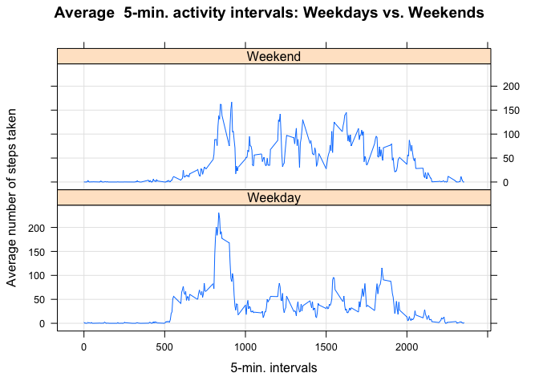

```r
data_byweekday <- aggregate(steps ~ interval + daylevel, data=new_data, FUN="mean")
xyplot(steps ~ interval | daylevel, data=data_byweekday, type="l", grid=T, layout=c(1,2), ylab="Average number of steps taken", xlab="5-min. intervals", main="Average  5-min. activity intervals: Weekdays vs. Weekends")
```